# Analisis Korespondensi

Nisrina Suci Fadila (G1401231021)

2025-12-10

# Analisis Korespondensi terhadap Preferensi Jenis Olahraga Berdasarkan Tingkat Pendidikan.

## Kasus dan Data

Dataset ini menggambarkan pilihan jenis olahraga berdasarkan tingkat pendidikan terakhir responden. Pendidikan mengacu pada latar belakang akademik konsumen, yang dibagi menjadi SMA, Diploma, Sarjana, dan Pascasarjana. Olahraga menunjukkan berbagai jenis aktivitas fisik yang diminati, seperti Sepak Bola, Bulutangkis, Yoga, Golf, dan Lari. Jumlah mencatatkan frekuensi responden yang memilih olahraga tersebut di setiap kategori pendidikan. Dataset ini digunakan untuk menganalisis bagaimana status pendidikan memengaruhi gaya hidup sehat seseorang, serta untuk mengidentifikasi segmen pasar yang paling potensial bagi fasilitas olahraga tertentu.”

```r
library(factoextra)
library(FactoMineR)
```

```r
library(gplots)
library(ca)
library(readxl)
olahraga <- read_xlsx("D:\\semester 5\\TPG\\data survey olahraga.xlsx")
olahraga
```

```
## # A tibble: 20 × 3
##    Pendidikan   Olahraga    Jumlah
##    <chr>        <chr>        <dbl>
##  1 SMA          Sepak Bola      60
##  2 Diploma      Sepak Bola      45
##  3 Sarjana      Sepak Bola      30
##  4 Pascasarjana Sepak Bola      10
##  5 SMA          Bulutangkis     40
##  6 Diploma      Bulutangkis     50
##  7 Sarjana      Bulutangkis     45
##  8 Pascasarjana Bulutangkis     20
##  9 SMA          Yoga            10
## 10 Diploma      Yoga            25
## 11 Sarjana      Yoga            50
## 12 Pascasarjana Yoga            40
## 13 SMA          Golf             2
## 14 Diploma      Golf             5
## 15 Sarjana      Golf            15
## 16 Pascasarjana Golf            40
## 17 SMA          Lari            20
## 18 Diploma      Lari            35
## 19 Sarjana      Lari            60
## 20 Pascasarjana Lari            30
```

## 1. Tabel Kontingensi

Dari data yang terbentuk, dapat kita bentuk tabel kontingensi sebagai berikut:

```r
olahraga$Pendididkan <- factor(olahraga$Pendidikan, levels=c("SMA", "Diploma",
                                                    "Sarjana", "Pascasarjana"))
olahraga$Olahraga <- factor(olahraga$Olahraga,
                                levels=c("Sepak Bola", "Bulutangkis",
                                         "Yoga","Golf","Lari"))
table_count <- xtabs(Jumlah ~ Pendididkan + Olahraga, data = olahraga)
table_count
```

```
##               Olahraga
## Pendididkan    Sepak Bola Bulutangkis Yoga Golf Lari
##   SMA                  60          40   10    2   20
##   Diploma              45          50   25    5   35
##   Sarjana              30          45   50   15   60
##   Pascasarjana         10          20   40   40   30
```

## 2. Eksplorasi Data

### Balloon Plot

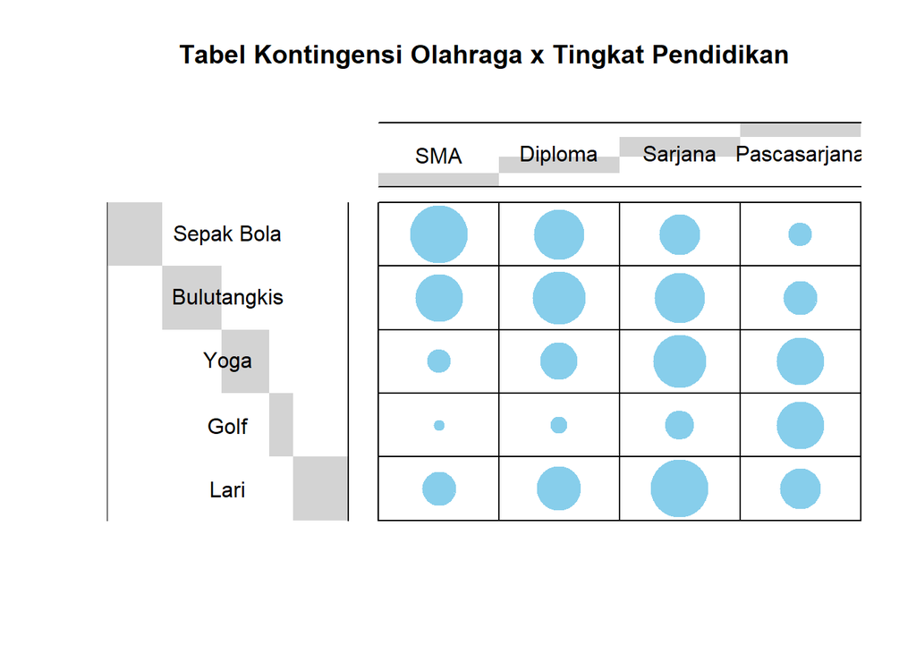

```r
balloonplot(table_count, main ="Tabel Kontingensi Olahraga x Tingkat Pendidikan", xlab ="", ylab="", label = FALSE, show.margins = FALSE)
```

Lingkaran menunjukkan seberapa besar nilai yang direpresentasikan, yaitu semakin besar lingkaran maka nilai yang direpresentasikan akan semakin besar pula.

### Uji Chi-Square

```r
chisq <- chisq.test(table_count)
chisq
```

```
##
##  Pearson's Chi-squared test
##
## data:  table_count
## X-squared = 158.31, df = 12, p-value < 2.2e-16
```

Hasil uji Chi-Square menunjukkan bahwa tingkat pendidikan dan jenis olahraga memiliki keterkaitan yang signifikan.

## 3. Membentuk Model

```r
model_olahraga <- CA(table_count, graph = F)
model_olahraga
```

```
## **Results of the Correspondence Analysis (CA)**
## The row variable has  4  categories; the column variable has 5 categories
## The chi square of independence between the two variables is equal to 158.3127 (p-value =  1.158879e-27 ).
## *The results are available in the following objects:
##
##    name              description
## 1  "$eig"            "eigenvalues"
## 2  "$col"            "results for the columns"
## 3  "$col$coord"      "coord. for the columns"
## 4  "$col$cos2"       "cos2 for the columns"
## 5  "$col$contrib"    "contributions of the columns"
## 6  "$row"            "results for the rows"
## 7  "$row$coord"      "coord. for the rows"
## 8  "$row$cos2"       "cos2 for the rows"
## 9  "$row$contrib"    "contributions of the rows"
## 10 "$call"           "summary called parameters"
## 11 "$call$marge.col" "weights of the columns"
## 12 "$call$marge.row" "weights of the rows"
```

### a. Akar/vektor ciri

```r
eig.val <- get_eigenvalue(model_olahraga)
eig.val
```

```
##        eigenvalue variance.percent cumulative.variance.percent
## Dim.1 0.212333875        84.765796                     84.7658
## Dim.2 0.036361821        14.516001                     99.2818
## Dim.3 0.001799061         0.718203                    100.0000
```

### b. Presentase keragaman

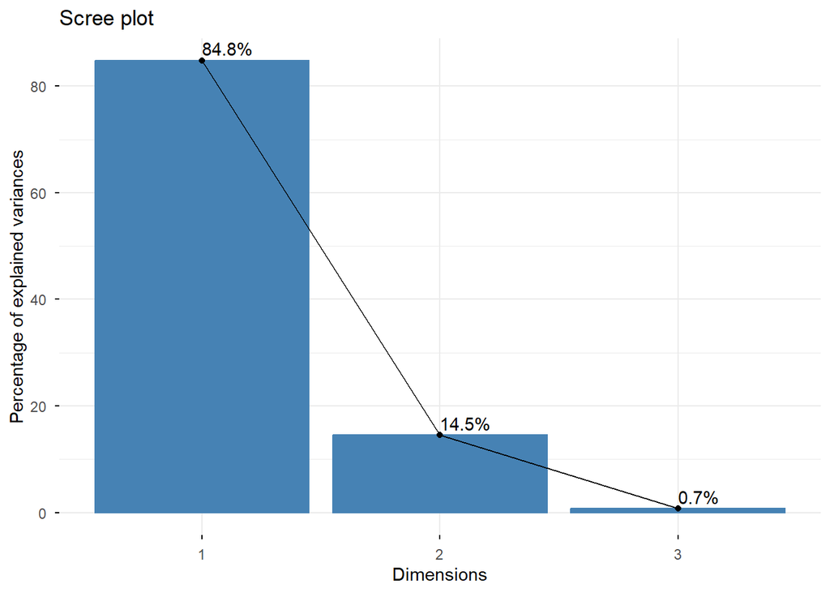

```r
fviz_screeplot(model_olahraga, addlabels = TRUE)
```

Dapat dilihat bahwa untuk mereduksi menjadi 2 dimensi saja, kita sudah mendapatkan 99.3% keragaman dalam data.

### c. Analisis dan visualisasi profil baris

```r
row <- get_ca_row(model_olahraga)
row
```

```
## Correspondence Analysis - Results for rows
##  ===================================================
##   Name       Description
## 1 "$coord"   "Coordinates for the rows"
## 2 "$cos2"    "Cos2 for the rows"
## 3 "$contrib" "contributions of the rows"
## 4 "$inertia" "Inertia of the rows"
```

### Koordinat dari profil baris

```r
row$coord
```

```
##                   Dim 1       Dim 2        Dim 3
## SMA          -0.5998602  0.21214732  0.039230985
## Diploma      -0.2781283 -0.05533985 -0.067084212
## Sarjana       0.1180435 -0.23479411  0.032254414
## Pascasarjana  0.7148098  0.19864110 -0.006399278
```

Untuk memetakan menjadi dua dimensi, maka hanya perlu melihat Dim 1 dan Dim 2 nya saja.

### Kontribusi keragaman profil baris

```r
row$contrib
```

```
##                  Dim 1     Dim 2      Dim 3
## SMA          35.394658 25.851534 17.8677317
## Diploma       9.223037  2.132226 63.3282808
## Sarjana       2.076720 47.977951 18.2997594
## Pascasarjana 53.305585 24.038288  0.5042281
```

### Plot profil baris

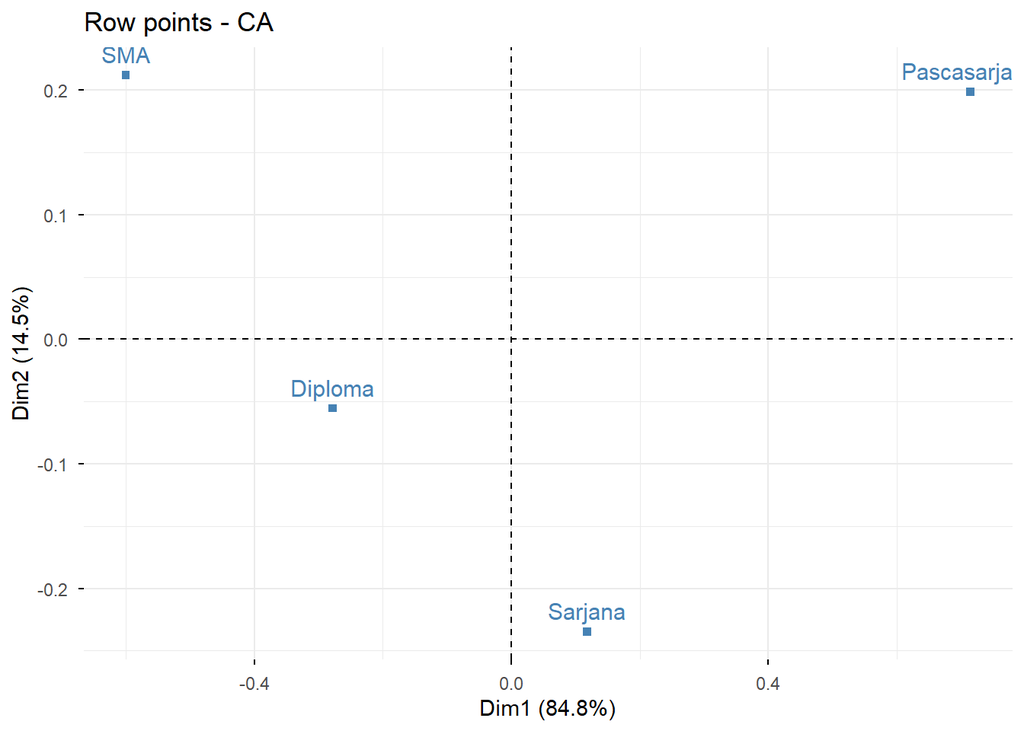

```r
fviz_ca_row(model_olahraga, col.row="steelblue", shape.row = 15)
```

– Baris dengan profil serupa dikelompokkan bersama. – Baris yang berkorelasi negatif diposisikan pada sisi yang saling berlawanan (kuadran berlawanan).

### d. Analisis dan visualisasi profil kolom

```r
col <- get_ca_col(model_olahraga)
col
```

```
## Correspondence Analysis - Results for columns
##  ===================================================
##   Name       Description
## 1 "$coord"   "Coordinates for the columns"
## 2 "$cos2"    "Cos2 for the columns"
## 3 "$contrib" "contributions of the columns"
## 4 "$inertia" "Inertia of the columns"
```

### Koordinat profil kolom

```r
col$coord
```

```
##                  Dim 1       Dim 2       Dim 3
## Sepak Bola  -0.5660056  0.18738462  0.03881309
## Bulutangkis -0.2561154 -0.02957083 -0.07019800
## Yoga         0.3740087 -0.12821316  0.01357134
## Golf         0.9721125  0.38665874 -0.01107101
## Lari         0.1017010 -0.21057578  0.02926053
```

Untuk memetakan menjadi dua dimensi, maka hanya perlu melihat Dim 1 dan Dim 2 nya saja.

### Kontribusi keragaman profil kolom

```r
col$contrib
```

```
##                 Dim 1     Dim 2      Dim 3
## Sepak Bola  34.615698 22.155073 19.2115105
## Bulutangkis  7.576469  0.589788 67.1766320
## Yoga        13.029777  8.941544  2.0248495
## Golf        43.660466 40.335241  0.6683486
## Lari         1.117589 27.978353 10.9186594
```

Profil kolom yang berkontribusi paling banyak kepada Dim 1 dan Dim 2 adalah baris yang paling penting dalam menjelaskan keragaman data. Dalam hal ini, olahraga Golf pada dimensi 1 maupun 2 dianggap sebagai olahraga yang menyumbang keragaman paling besar.

#### Plot profil kolom

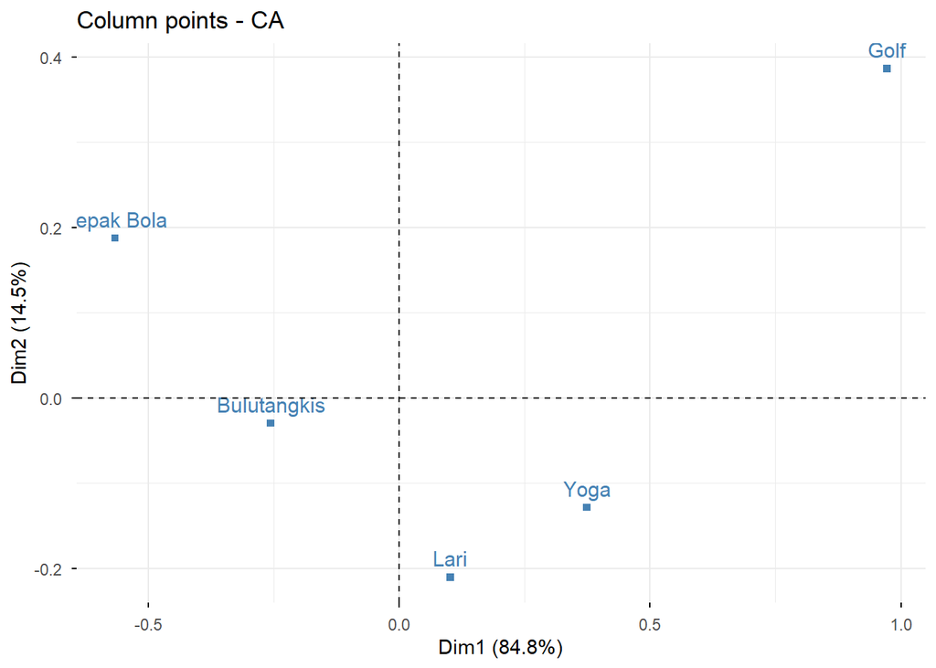

```r
fviz_ca_col(model_olahraga, col.col="steelblue", shape.col = 15)
```

### e. Pembentukan plot korespondensi

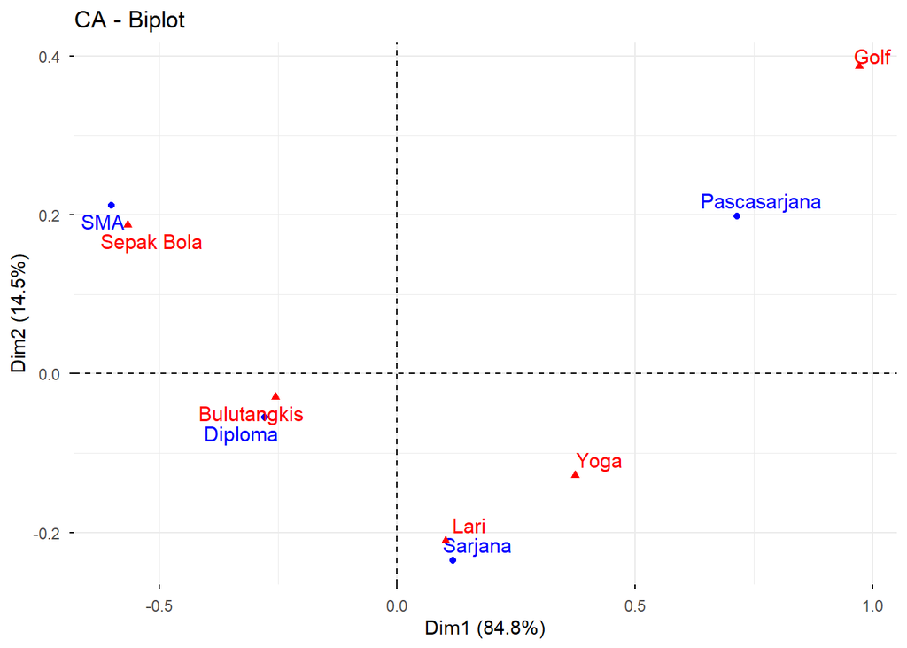

```r
fviz_ca_biplot(model_olahraga, repel = TRUE)
```

- Plot dalam gambar di atas, menunjukkan bagaimana korelasi antara olahraga favorit dengan berbagai kategori tingkat pendidikan.

*Kesimpulan* Hasil analisis menunjukkan asosiasi kuat antara tingkat pendidikan dan jenis olahraga: lulusan SMA lebih menyukai Sepak Bola, Diploma pada Bulutangkis, Sarjana pada Lari dan Yoga, serta Pascasarjana pada Golf. Dengan nilai inersia 99,3%, plot ini sangat akurat membuktikan bahwa semakin tinggi jenjang pendidikan, preferensi olahraga cenderung bergeser dari olahraga beregu menuju olahraga individu atau gaya hidup.